# Classification

you

2022-10-18

## Generating simulated data

The true model in this case is a logistic regression model.

Check: Can you understand the true data generating process by reading the code?

```r
# Setting parameters
set.seed(1)
# Try changing some parameters
n <- 500
p <- 4
sparsity <- 2
nonzero_beta <-
  rep(1, sparsity) # or e.g. runif(sparsity, min = -1, max = 1)
true_beta <- c(nonzero_beta, rep(0, p - sparsity))
class_shift <- 2.5 # change this
```

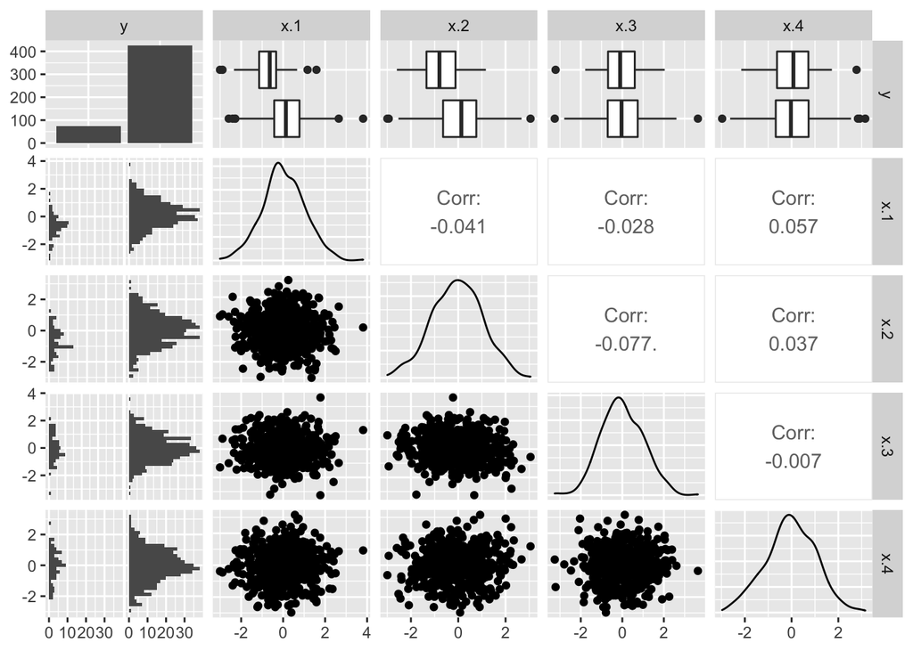

```r
# Generating simulated data
X <- matrix(rnorm(n*p), nrow = n)
mu <- class_shift + X %*% true_beta
px <- exp(mu)/(1+exp(mu))
Y <- rbinom(n, 1, prob = px)
train_ld <- data.frame(y = as.factor(Y), x = X)
train_ld |>
  select(y, num_range("x.", 1:4)) |>
  ggpairs(progress = F)
```

Check: Do these plots fit with your understanding of the true data generating process?

```r
# Class (im)balance
table(train_ld$y)
```

```
##
##   0   1
##  74 426
```

**Question**: What would the accuracy be for a classifier that always predicts the most common class?

```r
const_yhat_success <- mean(train_ld$y == 1)
```

## Logistic regression model

### Coefficients

```r
c(class_shift, true_beta)
```

```
## [1] 2.5 1.0 1.0 0.0 0.0
```

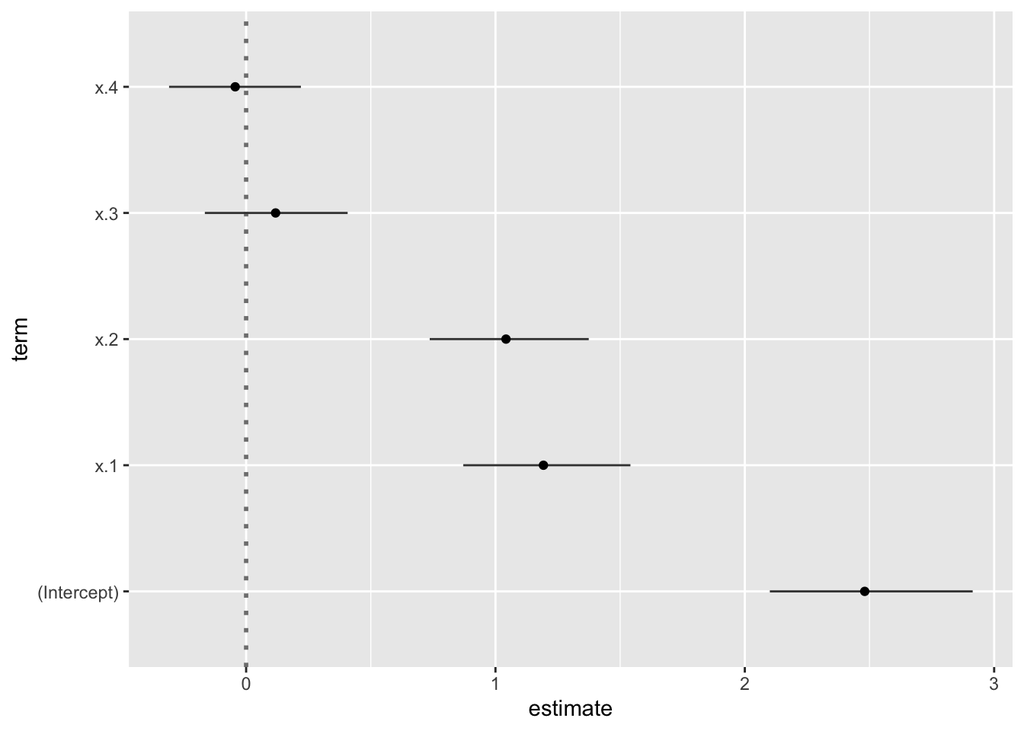

```r
fit_glm <- glm(y ~ ., family = binomial(), data = train_ld)
fit_glm |> ggcoef()
```

```r
#fit_glm |> tidy(?)
```

### Predictions

```r
fit_glm_predictions <- augment(fit_glm, type.predict = "response")
fit_glm_predictions |> pull(.fitted) |> mean()
```

```
## [1] 0.852
```

**Question**: Does this number look familiar? Why?

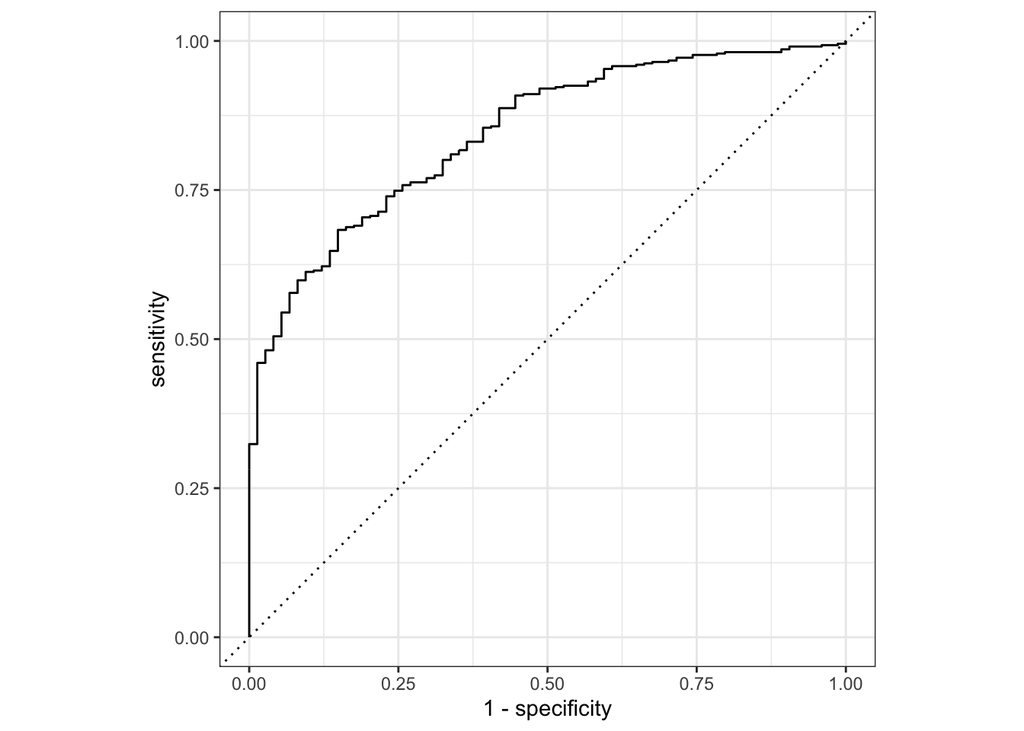

```r
# Note: the event_level option is currently required because
# of a mismatch between glm() and yardstick
fit_glm_predictions |>
  roc_curve(truth = y, .fitted,
            event_level = "second") |>
  autoplot()
```

**Note**: When a classification model outputs class probabilities or numeric scores these can be converted into classifications by setting thresholds or cutoffs. If we keep the model fixed but change the cutoff, we can achieve different trade-offs between false positives and false negatives (or specificity and sensitivity, precision and recall, etc–these are just other names). Plots like this `roc_curve` (see also `?pr_curve`) show all the possible trade-off values for one model.

**Question**: Using curves like this how can we compare different models? Give at least two suggestions.

Classify at several different thresholds

```r
# Note: true and predicted classes must use same
# label names, hence the factor(as.numeric())
higher_cutoff <- const_yhat_success + .05
confusion_matrix_higher <-
  fit_glm_predictions |>
  mutate(yhat = factor(as.numeric(.fitted > higher_cutoff))) |>
  conf_mat(truth = y, estimate = yhat)
```

```r
lower_cutoff <- .2
confusion_matrix_lower <-
  fit_glm_predictions |>
  mutate(yhat = factor(as.numeric(.fitted > lower_cutoff))) |>
  conf_mat(truth = y, estimate = yhat)
```

```r
confusion_matrix_higher
```

```
##           Truth
## Prediction   0   1
##          0  65 164
##          1   9 262
```

```r
confusion_matrix_lower
```

```
##           Truth
## Prediction   0   1
##          0   0   2
##          1  74 424
```

Comparing across various metrics:

```r
higher_summary <- summary(confusion_matrix_higher) |>
  mutate(higher = .estimate) |>
  select(.metric, higher)
lower_summary <- summary(confusion_matrix_lower) |>
  mutate(lower = .estimate) |>
  select(lower)
cbind(higher_summary, lower_summary)
```

```
##                 .metric    higher        lower
## 1              accuracy 0.6540000  0.848000000
## 2                   kap 0.2645058 -0.007850626
## 3                  sens 0.8783784  0.000000000
## 4                  spec 0.6150235  0.995305164
## 5                   ppv 0.2838428  0.000000000
## 6                   npv 0.9667897  0.851405622
## 7                   mcc 0.3516568 -0.026412614
## 8               j_index 0.4934019 -0.004694836
## 9          bal_accuracy 0.7467009  0.497652582
## 10 detection_prevalence 0.4580000  0.004000000
## 11            precision 0.2838428  0.000000000
## 12               recall 0.8783784  0.000000000
## 13               f_meas 0.4290429  0.000000000
```

Note the `accuracy`, for example, which is the proportion of data where the predicted class and true class are equal.

### Sub-sampling for class balance

```r
rare_class_size <- min(table(train_ld$y))
train_subsampled <- train_ld |>
  group_by(y) |>
  sample_n(rare_class_size) |>
  ungroup()

fit_glm_subs <- glm(y ~ ., family = binomial(), data = train_subsampled)
```

Does this change coefficients or inferences about them?

```r
cbind(
  tidy(fit_glm) |> select(term, estimate, std.error),
  tidy(fit_glm_subs) |> select(estimate, std.error)) |>
  knitr::kable()
```

| term | estimate | std.error | estimate | std.error |
| --- | --- | --- | --- | --- |
| (Intercept) | 2.4808879 | 0.2067843 | 0.8869130 | 0.2734060 |
| x.1 | 1.1923946 | 0.1704925 | 1.6250092 | 0.2957344 |
| x.2 | 1.0422221 | 0.1622098 | 1.1683666 | 0.2551454 |
| x.3 | 0.1181967 | 0.1456378 | 0.2936595 | 0.2475284 |
| x.4 | -0.0438562 | 0.1344844 | 0.0915651 | 0.1980801 |

**Note**: With a smaller sample size, the balanced training data gives us larger `std.errors` for our estimates. (Wider confident intervals, larger p-values).

```r
fit_glm_subs_predictions <- augment(fit_glm_subs, type.predict = "response")
fit_glm_subs_predictions |> pull(.fitted) |> mean()
```

```
## [1] 0.5
```

Training data classes are balanced so the predictions are also balanced.

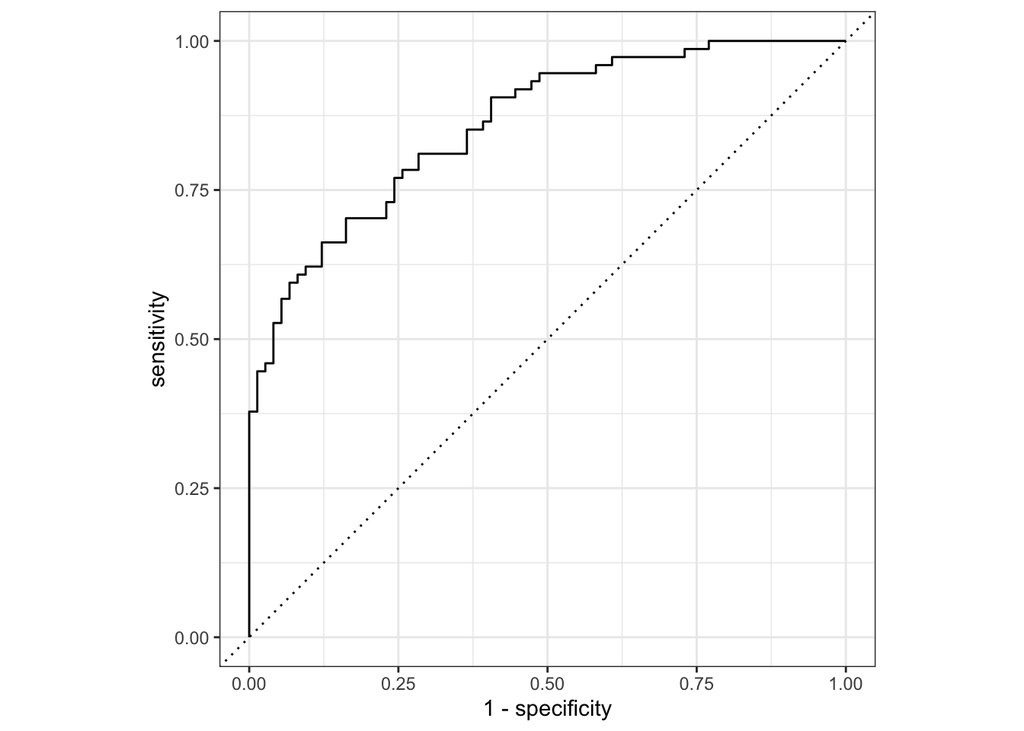

```r
# Note: the event_level option is currently required because
# of a mismatch between glm() and yardstick
fit_glm_subs_predictions |>
  roc_curve(truth = y, .fitted,
            event_level = "second") |>
  autoplot()
```

Classify at several different thresholds

```r
# Note: true and predicted classes must use same
# label names, hence the factor(as.numeric())
higher_cutoff <- const_yhat_success + .05
confusion_matrix_subs_higher <-
  fit_glm_subs_predictions |>
  mutate(yhat = factor(as.numeric(.fitted > higher_cutoff))) |>
  conf_mat(truth = y, estimate = yhat)
```

```r
lower_cutoff <- .2
confusion_matrix_subs_lower <-
  fit_glm_subs_predictions |>
  mutate(yhat = factor(as.numeric(.fitted > lower_cutoff))) |>
  conf_mat(truth = y, estimate = yhat)
```

```r
confusion_matrix_subs_higher
```

```
##           Truth
## Prediction  0  1
##          0 74 48
##          1  0 26
```

```r
confusion_matrix_subs_lower
```

```
##           Truth
## Prediction  0  1
##          0 35  4
##          1 39 70
```

Comparing across various metrics:

```r
higher_subs_summary <- summary(confusion_matrix_subs_higher) |>
  mutate(higher = .estimate) |>
  select(.metric, higher)
lower_subs_summary <- summary(confusion_matrix_subs_lower) |>
  mutate(lower = .estimate) |>
  select(lower)
metrics <- c("accuracy", "bal_accuracy") #, "precision", "recall")
rbind(
cbind(higher_summary, lower_summary) |>
  filter(.metric %in% metrics) |>
  mutate(subsampled = FALSE),
cbind(higher_subs_summary, lower_subs_summary) |>
  filter(.metric %in% metrics) |>
  mutate(subsampled = TRUE))
```

```
##        .metric    higher     lower subsampled
## 1     accuracy 0.6540000 0.8480000      FALSE
## 2 bal_accuracy 0.7467009 0.4976526      FALSE
## 3     accuracy 0.6756757 0.7094595       TRUE
## 4 bal_accuracy 0.6756757 0.7094595       TRUE
```

**Question**: Suppose we have trained a model on data that was subsampled to create class balance. Then we choose classification cutoffs to achieve a desired trade-off between precision/recall (or false positives and false negatives), and we do this still while using the subsampled training data. What will happen if we start using that model to classify data from a new or full dataset that hasn’t been subsampled?